# Risk Factor Analysis

## Outcome Variable

**Outcome Variable:** ever_co

## Predictor Variables

**Intervention Variable:** hdlvry

**Adjustment Set:**

- arm
- sex
- W_mage
- meducyrs
- feducyrs
- hhwealth_quart
- W_nrooms
- brthmon
- W_parity
- impsan
- delta_W_mage
- delta_meducyrs
- delta_feducyrs
- delta_hhwealth_quart
- delta_W_nrooms
- delta_brthmon
- delta_W_parity
- delta_impsan

## Stratifying Variables

The analysis was stratified on these variable(s):

- agecat
- studyid
- country

## Data Summary

| agecat | studyid | country | hdlvry | ever_co | n_cell | n |
| --- | --- | --- | --- | --- | --- | --- |
| 0-24 months | ki1000108-CMC-V-BCS-2002 | INDIA | 0 | 0 | 279 | 370 |
| 0-24 months | ki1000108-CMC-V-BCS-2002 | INDIA | 0 | 1 | 83 | 370 |
| 0-24 months | ki1000108-CMC-V-BCS-2002 | INDIA | 1 | 0 | 7 | 370 |
| 0-24 months | ki1000108-CMC-V-BCS-2002 | INDIA | 1 | 1 | 1 | 370 |
| 0-24 months | ki1000108-IRC | INDIA | 0 | 0 | 328 | 410 |
| 0-24 months | ki1000108-IRC | INDIA | 0 | 1 | 74 | 410 |
| 0-24 months | ki1000108-IRC | INDIA | 1 | 0 | 6 | 410 |
| 0-24 months | ki1000108-IRC | INDIA | 1 | 1 | 2 | 410 |
| 0-24 months | ki1000109-EE | PAKISTAN | 0 | 0 | 160 | 377 |
| 0-24 months | ki1000109-EE | PAKISTAN | 0 | 1 | 93 | 377 |
| 0-24 months | ki1000109-EE | PAKISTAN | 1 | 0 | 74 | 377 |
| 0-24 months | ki1000109-EE | PAKISTAN | 1 | 1 | 50 | 377 |
| 0-24 months | ki1000304b-SAS-CompFeed | INDIA | 0 | 0 | 140 | 1232 |
| 0-24 months | ki1000304b-SAS-CompFeed | INDIA | 0 | 1 | 24 | 1232 |
| 0-24 months | ki1000304b-SAS-CompFeed | INDIA | 1 | 0 | 795 | 1232 |
| 0-24 months | ki1000304b-SAS-CompFeed | INDIA | 1 | 1 | 273 | 1232 |
| 0-24 months | ki1000304b-SAS-FoodSuppl | INDIA | 0 | 0 | 55 | 418 |
| 0-24 months | ki1000304b-SAS-FoodSuppl | INDIA | 0 | 1 | 26 | 418 |
| 0-24 months | ki1000304b-SAS-FoodSuppl | INDIA | 1 | 0 | 208 | 418 |
| 0-24 months | ki1000304b-SAS-FoodSuppl | INDIA | 1 | 1 | 129 | 418 |
| 0-24 months | ki1017093b-PROVIDE | BANGLADESH | 0 | 0 | 456 | 700 |
| 0-24 months | ki1017093b-PROVIDE | BANGLADESH | 0 | 1 | 63 | 700 |
| 0-24 months | ki1017093b-PROVIDE | BANGLADESH | 1 | 0 | 154 | 700 |
| 0-24 months | ki1017093b-PROVIDE | BANGLADESH | 1 | 1 | 27 | 700 |
| 0-24 months | ki1017093c-NIH-Crypto | BANGLADESH | 0 | 0 | 545 | 758 |
| 0-24 months | ki1017093c-NIH-Crypto | BANGLADESH | 0 | 1 | 45 | 758 |
| 0-24 months | ki1017093c-NIH-Crypto | BANGLADESH | 1 | 0 | 142 | 758 |
| 0-24 months | ki1017093c-NIH-Crypto | BANGLADESH | 1 | 1 | 26 | 758 |
| 0-24 months | ki1066203-TanzaniaChild2 | TANZANIA, UNITED REPUBLIC OF | 0 | 0 | 2121 | 2274 |
| 0-24 months | ki1066203-TanzaniaChild2 | TANZANIA, UNITED REPUBLIC OF | 0 | 1 | 113 | 2274 |

[output cut: 114 more lines]

The following strata were considered:

- agecat: 0-24 months, studyid: ki1000108-CMC-V-BCS-2002, country: INDIA
- agecat: 0-24 months, studyid: ki1000108-IRC, country: INDIA
- agecat: 0-24 months, studyid: ki1000109-EE, country: PAKISTAN
- agecat: 0-24 months, studyid: ki1000304b-SAS-CompFeed, country: INDIA
- agecat: 0-24 months, studyid: ki1000304b-SAS-FoodSuppl, country: INDIA
- agecat: 0-24 months, studyid: ki1017093b-PROVIDE, country: BANGLADESH
- agecat: 0-24 months, studyid: ki1017093c-NIH-Crypto, country: BANGLADESH
- agecat: 0-24 months, studyid: ki1066203-TanzaniaChild2, country: TANZANIA, UNITED REPUBLIC OF
- agecat: 0-24 months, studyid: ki1113344-GMS-Nepal, country: NEPAL
- agecat: 0-24 months, studyid: ki1135781-COHORTS, country: INDIA
- agecat: 0-24 months, studyid: kiGH5241-JiVitA-3, country: BANGLADESH
- agecat: 0-24 months, studyid: kiGH5241-JiVitA-4, country: BANGLADESH
- agecat: 0-6 months, studyid: ki1000108-CMC-V-BCS-2002, country: INDIA
- agecat: 0-6 months, studyid: ki1000108-IRC, country: INDIA
- agecat: 0-6 months, studyid: ki1000109-EE, country: PAKISTAN
- agecat: 0-6 months, studyid: ki1000304b-SAS-CompFeed, country: INDIA
- agecat: 0-6 months, studyid: ki1000304b-SAS-FoodSuppl, country: INDIA
- agecat: 0-6 months, studyid: ki1017093b-PROVIDE, country: BANGLADESH
- agecat: 0-6 months, studyid: ki1017093c-NIH-Crypto, country: BANGLADESH
- agecat: 0-6 months, studyid: ki1066203-TanzaniaChild2, country: TANZANIA, UNITED REPUBLIC OF
- agecat: 0-6 months, studyid: ki1113344-GMS-Nepal, country: NEPAL
- agecat: 0-6 months, studyid: ki1135781-COHORTS, country: INDIA
- agecat: 0-6 months, studyid: kiGH5241-JiVitA-3, country: BANGLADESH
- agecat: 0-6 months, studyid: kiGH5241-JiVitA-4, country: BANGLADESH
- agecat: 6-24 months, studyid: ki1000108-CMC-V-BCS-2002, country: INDIA
- agecat: 6-24 months, studyid: ki1000108-IRC, country: INDIA
- agecat: 6-24 months, studyid: ki1000109-EE, country: PAKISTAN
- agecat: 6-24 months, studyid: ki1000304b-SAS-CompFeed, country: INDIA
- agecat: 6-24 months, studyid: ki1000304b-SAS-FoodSuppl, country: INDIA
- agecat: 6-24 months, studyid: ki1017093b-PROVIDE, country: BANGLADESH
- agecat: 6-24 months, studyid: ki1017093c-NIH-Crypto, country: BANGLADESH
- agecat: 6-24 months, studyid: ki1066203-TanzaniaChild2, country: TANZANIA, UNITED REPUBLIC OF
- agecat: 6-24 months, studyid: ki1113344-GMS-Nepal, country: NEPAL
- agecat: 6-24 months, studyid: ki1135781-COHORTS, country: INDIA
- agecat: 6-24 months, studyid: kiGH5241-JiVitA-3, country: BANGLADESH
- agecat: 6-24 months, studyid: kiGH5241-JiVitA-4, country: BANGLADESH

### Dropped Strata

Some strata were dropped due to rare outcomes:

- agecat: 0-24 months, studyid: ki1000108-CMC-V-BCS-2002, country: INDIA
- agecat: 0-24 months, studyid: ki1000108-IRC, country: INDIA
- agecat: 0-24 months, studyid: ki1066203-TanzaniaChild2, country: TANZANIA, UNITED REPUBLIC OF
- agecat: 0-24 months, studyid: kiGH5241-JiVitA-3, country: BANGLADESH
- agecat: 0-6 months, studyid: ki1000108-CMC-V-BCS-2002, country: INDIA
- agecat: 0-6 months, studyid: ki1000108-IRC, country: INDIA
- agecat: 0-6 months, studyid: ki1000304b-SAS-CompFeed, country: INDIA
- agecat: 0-6 months, studyid: ki1000304b-SAS-FoodSuppl, country: INDIA
- agecat: 0-6 months, studyid: ki1066203-TanzaniaChild2, country: TANZANIA, UNITED REPUBLIC OF
- agecat: 0-6 months, studyid: ki1113344-GMS-Nepal, country: NEPAL
- agecat: 0-6 months, studyid: kiGH5241-JiVitA-3, country: BANGLADESH
- agecat: 6-24 months, studyid: ki1000108-CMC-V-BCS-2002, country: INDIA
- agecat: 6-24 months, studyid: ki1000108-IRC, country: INDIA
- agecat: 6-24 months, studyid: ki1066203-TanzaniaChild2, country: TANZANIA, UNITED REPUBLIC OF
- agecat: 6-24 months, studyid: kiGH5241-JiVitA-3, country: BANGLADESH

## Methods Detail

We’re interested in the causal parameters $E[Y_a]$ for all values of $a \in \mathcal{A}$. These parameters represent the mean outcome if, possibly contrary to fact, we intervened to set all units to have $A=a$. Under the randomization and positivity assumptions, these are identified by the statistical parameters $\psi_a=E_W[E_{Y|A,W}(Y|A=a,W)]$. In addition, we’re interested in the mean of $Y$, $E[Y]$ under no intervention (the observed mean). We will estimate these parameters by using SuperLearner to fit the relevant likelihood factors – $E_{Y|A,W}(Y|A=a,W)$ and $p(A=a|W)$, and then updating our likelihood fit using a joint TMLE.

For unadjusted analyses ($W=\{\}$), initial likelihoods were estimated using Lrnr_glm to estimate the simple $E(Y|A)$ and Lrnr_mean to estimate $p(A)$. For adjusted analyses, a small library containing Lrnr_glmnet, Lrnr_xgboost, and Lrnr_mean was used.

Having estimated these parameters, we will then use the delta method to estimate relative risks and attributable risks relative to a prespecified baseline level of $A$.

# Results Detail

## Results Plots

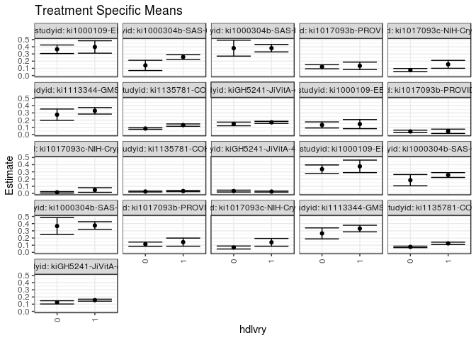

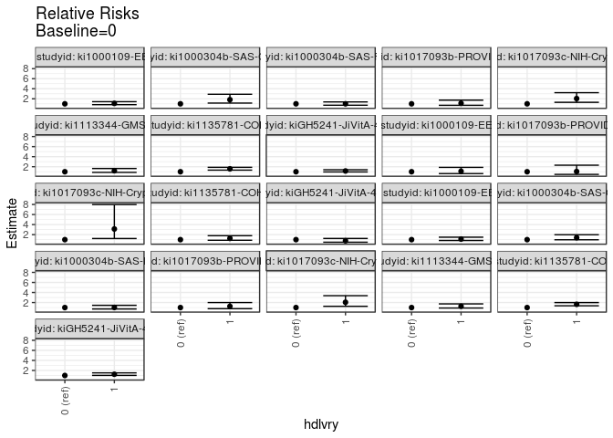

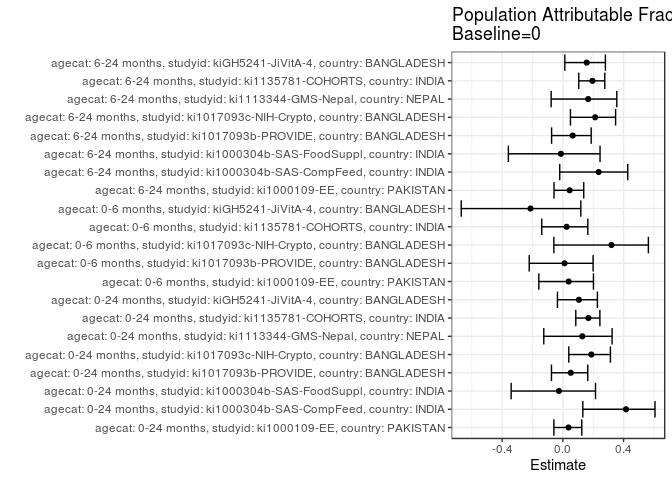

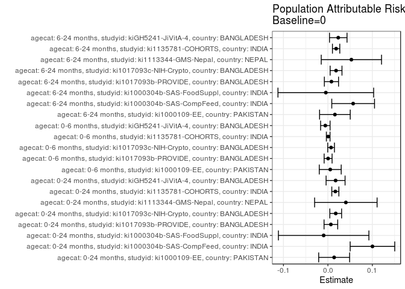

## Results Table

### Parameter: TSM

| agecat | studyid | country | intervention_level | baseline_level | estimate | ci_lower | ci_upper |
| --- | --- | --- | --- | --- | --- | --- | --- |
| 0-24 months | ki1000109-EE | PAKISTAN | 0 | NA | 0.3652674 | 0.3056187 | 0.4249160 |
| 0-24 months | ki1000109-EE | PAKISTAN | 1 | NA | 0.3968766 | 0.3106595 | 0.4830937 |
| 0-24 months | ki1000304b-SAS-CompFeed | INDIA | 0 | NA | 0.1408475 | 0.0696116 | 0.2120834 |
| 0-24 months | ki1000304b-SAS-CompFeed | INDIA | 1 | NA | 0.2571950 | 0.2245968 | 0.2897932 |
| 0-24 months | ki1000304b-SAS-FoodSuppl | INDIA | 0 | NA | 0.3803893 | 0.2696498 | 0.4911288 |
| 0-24 months | ki1000304b-SAS-FoodSuppl | INDIA | 1 | NA | 0.3806581 | 0.3285449 | 0.4327714 |
| 0-24 months | ki1017093b-PROVIDE | BANGLADESH | 0 | NA | 0.1218930 | 0.0937513 | 0.1500347 |
| 0-24 months | ki1017093b-PROVIDE | BANGLADESH | 1 | NA | 0.1347990 | 0.0827884 | 0.1868095 |
| 0-24 months | ki1017093c-NIH-Crypto | BANGLADESH | 0 | NA | 0.0760959 | 0.0546437 | 0.0975482 |
| 0-24 months | ki1017093c-NIH-Crypto | BANGLADESH | 1 | NA | 0.1555315 | 0.1003005 | 0.2107626 |
| 0-24 months | ki1113344-GMS-Nepal | NEPAL | 0 | NA | 0.2751623 | 0.1963865 | 0.3539380 |
| 0-24 months | ki1113344-GMS-Nepal | NEPAL | 1 | NA | 0.3290846 | 0.2838783 | 0.3742908 |
| 0-24 months | ki1135781-COHORTS | INDIA | 0 | NA | 0.0827019 | 0.0721607 | 0.0932431 |
| 0-24 months | ki1135781-COHORTS | INDIA | 1 | NA | 0.1303871 | 0.1143887 | 0.1463855 |
| 0-24 months | kiGH5241-JiVitA-4 | BANGLADESH | 0 | NA | 0.1464664 | 0.1208971 | 0.1720357 |
| 0-24 months | kiGH5241-JiVitA-4 | BANGLADESH | 1 | NA | 0.1689415 | 0.1548920 | 0.1829910 |
| 0-6 months | ki1000109-EE | PAKISTAN | 0 | NA | 0.1326653 | 0.0905332 | 0.1747974 |
| 0-6 months | ki1000109-EE | PAKISTAN | 1 | NA | 0.1443825 | 0.0812878 | 0.2074771 |
| 0-6 months | ki1017093b-PROVIDE | BANGLADESH | 0 | NA | 0.0423892 | 0.0250433 | 0.0597351 |
| 0-6 months | ki1017093b-PROVIDE | BANGLADESH | 1 | NA | 0.0441989 | 0.0142343 | 0.0741635 |
| 0-6 months | ki1017093c-NIH-Crypto | BANGLADESH | 0 | NA | 0.0152542 | 0.0053581 | 0.0251504 |
| 0-6 months | ki1017093c-NIH-Crypto | BANGLADESH | 1 | NA | 0.0476190 | 0.0153953 | 0.0798428 |
| 0-6 months | ki1135781-COHORTS | INDIA | 0 | NA | 0.0265248 | 0.0204587 | 0.0325909 |
| 0-6 months | ki1135781-COHORTS | INDIA | 1 | NA | 0.0331426 | 0.0240975 | 0.0421878 |
| 0-6 months | kiGH5241-JiVitA-4 | BANGLADESH | 0 | NA | 0.0329463 | 0.0199330 | 0.0459596 |
| 0-6 months | kiGH5241-JiVitA-4 | BANGLADESH | 1 | NA | 0.0257116 | 0.0189087 | 0.0325145 |
| 6-24 months | ki1000109-EE | PAKISTAN | 0 | NA | 0.3373615 | 0.2785017 | 0.3962214 |
| 6-24 months | ki1000109-EE | PAKISTAN | 1 | NA | 0.3765943 | 0.2897989 | 0.4633897 |
| 6-24 months | ki1000304b-SAS-CompFeed | INDIA | 0 | NA | 0.1843486 | 0.1059489 | 0.2627482 |
| 6-24 months | ki1000304b-SAS-CompFeed | INDIA | 1 | NA | 0.2562194 | 0.2228711 | 0.2895678 |
| 6-24 months | ki1000304b-SAS-FoodSuppl | INDIA | 0 | NA | 0.3663056 | 0.2494162 | 0.4831949 |
| 6-24 months | ki1000304b-SAS-FoodSuppl | INDIA | 1 | NA | 0.3736172 | 0.3205991 | 0.4266354 |
| 6-24 months | ki1017093b-PROVIDE | BANGLADESH | 0 | NA | 0.1141823 | 0.0851704 | 0.1431941 |
| 6-24 months | ki1017093b-PROVIDE | BANGLADESH | 1 | NA | 0.1425140 | 0.0862333 | 0.1987946 |
| 6-24 months | ki1017093c-NIH-Crypto | BANGLADESH | 0 | NA | 0.0679516 | 0.0471012 | 0.0888019 |
| 6-24 months | ki1017093c-NIH-Crypto | BANGLADESH | 1 | NA | 0.1397592 | 0.0857443 | 0.1937742 |
| 6-24 months | ki1113344-GMS-Nepal | NEPAL | 0 | NA | 0.2641160 | 0.1877272 | 0.3405048 |
| 6-24 months | ki1113344-GMS-Nepal | NEPAL | 1 | NA | 0.3313058 | 0.2857007 | 0.3769110 |
| 6-24 months | ki1135781-COHORTS | INDIA | 0 | NA | 0.0762592 | 0.0656377 | 0.0868807 |
| 6-24 months | ki1135781-COHORTS | INDIA | 1 | NA | 0.1253208 | 0.1087194 | 0.1419222 |
| 6-24 months | kiGH5241-JiVitA-4 | BANGLADESH | 0 | NA | 0.1249771 | 0.1023331 | 0.1476212 |
| 6-24 months | kiGH5241-JiVitA-4 | BANGLADESH | 1 | NA | 0.1553416 | 0.1415406 | 0.1691427 |

### Parameter: E(Y)

| agecat | studyid | country | intervention_level | baseline_level | estimate | ci_lower | ci_upper |
| --- | --- | --- | --- | --- | --- | --- | --- |
| 0-24 months | ki1000109-EE | PAKISTAN | NA | NA | 0.3793103 | 0.3302660 | 0.4283547 |
| 0-24 months | ki1000304b-SAS-CompFeed | INDIA | NA | NA | 0.2410714 | 0.1975050 | 0.2846379 |
| 0-24 months | ki1000304b-SAS-FoodSuppl | INDIA | NA | NA | 0.3708134 | 0.3244530 | 0.4171738 |
| 0-24 months | ki1017093b-PROVIDE | BANGLADESH | NA | NA | 0.1285714 | 0.1037574 | 0.1533855 |
| 0-24 months | ki1017093c-NIH-Crypto | BANGLADESH | NA | NA | 0.0936675 | 0.0729118 | 0.1144233 |
| 0-24 months | ki1113344-GMS-Nepal | NEPAL | NA | NA | 0.3155080 | 0.2770184 | 0.3539976 |
| 0-24 months | ki1135781-COHORTS | INDIA | NA | NA | 0.0994301 | 0.0912079 | 0.1076524 |
| 0-24 months | kiGH5241-JiVitA-4 | BANGLADESH | NA | NA | 0.1637414 | 0.1510998 | 0.1763830 |
| 0-6 months | ki1000109-EE | PAKISTAN | NA | NA | 0.1379310 | 0.1030768 | 0.1727853 |
| 0-6 months | ki1017093b-PROVIDE | BANGLADESH | NA | NA | 0.0428571 | 0.0278427 | 0.0578716 |
| 0-6 months | ki1017093c-NIH-Crypto | BANGLADESH | NA | NA | 0.0224274 | 0.0118796 | 0.0329753 |
| 0-6 months | ki1135781-COHORTS | INDIA | NA | NA | 0.0271860 | 0.0226456 | 0.0317265 |
| 0-6 months | kiGH5241-JiVitA-4 | BANGLADESH | NA | NA | 0.0271544 | 0.0212424 | 0.0330664 |
| 6-24 months | ki1000109-EE | PAKISTAN | NA | NA | 0.3530997 | 0.3044013 | 0.4017981 |
| 6-24 months | ki1000304b-SAS-CompFeed | INDIA | NA | NA | 0.2411348 | 0.1953341 | 0.2869354 |
| 6-24 months | ki1000304b-SAS-FoodSuppl | INDIA | NA | NA | 0.3615960 | 0.3145115 | 0.4086805 |
| 6-24 months | ki1017093b-PROVIDE | BANGLADESH | NA | NA | 0.1221498 | 0.0962275 | 0.1480722 |
| 6-24 months | ki1017093c-NIH-Crypto | BANGLADESH | NA | NA | 0.0863014 | 0.0659171 | 0.1066856 |
| 6-24 months | ki1113344-GMS-Nepal | NEPAL | NA | NA | 0.3169399 | 0.2779838 | 0.3558960 |
| 6-24 months | ki1135781-COHORTS | INDIA | NA | NA | 0.0947257 | 0.0863884 | 0.1030631 |
| 6-24 months | kiGH5241-JiVitA-4 | BANGLADESH | NA | NA | 0.1482636 | 0.1364361 | 0.1600910 |

### Parameter: RR

| agecat | studyid | country | intervention_level | baseline_level | estimate | ci_lower | ci_upper |
| --- | --- | --- | --- | --- | --- | --- | --- |
| 0-24 months | ki1000109-EE | PAKISTAN | 0 | 0 | 1.0000000 | 1.0000000 | 1.000000 |
| 0-24 months | ki1000109-EE | PAKISTAN | 1 | 0 | 1.0865372 | 0.8286397 | 1.424700 |
| 0-24 months | ki1000304b-SAS-CompFeed | INDIA | 0 | 0 | 1.0000000 | 1.0000000 | 1.000000 |
| 0-24 months | ki1000304b-SAS-CompFeed | INDIA | 1 | 0 | 1.8260524 | 1.1480311 | 2.904510 |
| 0-24 months | ki1000304b-SAS-FoodSuppl | INDIA | 0 | 0 | 1.0000000 | 1.0000000 | 1.000000 |
| 0-24 months | ki1000304b-SAS-FoodSuppl | INDIA | 1 | 0 | 1.0007067 | 0.7255626 | 1.380190 |
| 0-24 months | ki1017093b-PROVIDE | BANGLADESH | 0 | 0 | 1.0000000 | 1.0000000 | 1.000000 |
| 0-24 months | ki1017093b-PROVIDE | BANGLADESH | 1 | 0 | 1.1058794 | 0.7050749 | 1.734524 |
| 0-24 months | ki1017093c-NIH-Crypto | BANGLADESH | 0 | 0 | 1.0000000 | 1.0000000 | 1.000000 |
| 0-24 months | ki1017093c-NIH-Crypto | BANGLADESH | 1 | 0 | 2.0438882 | 1.2983124 | 3.217622 |
| 0-24 months | ki1113344-GMS-Nepal | NEPAL | 0 | 0 | 1.0000000 | 1.0000000 | 1.000000 |
| 0-24 months | ki1113344-GMS-Nepal | NEPAL | 1 | 0 | 1.1959654 | 0.8702795 | 1.643533 |
| 0-24 months | ki1135781-COHORTS | INDIA | 0 | 0 | 1.0000000 | 1.0000000 | 1.000000 |
| 0-24 months | ki1135781-COHORTS | INDIA | 1 | 0 | 1.5765904 | 1.3216825 | 1.880661 |
| 0-24 months | kiGH5241-JiVitA-4 | BANGLADESH | 0 | 0 | 1.0000000 | 1.0000000 | 1.000000 |
| 0-24 months | kiGH5241-JiVitA-4 | BANGLADESH | 1 | 0 | 1.1534489 | 0.9549492 | 1.393210 |
| 0-6 months | ki1000109-EE | PAKISTAN | 0 | 0 | 1.0000000 | 1.0000000 | 1.000000 |
| 0-6 months | ki1000109-EE | PAKISTAN | 1 | 0 | 1.0883215 | 0.6346307 | 1.866351 |
| 0-6 months | ki1017093b-PROVIDE | BANGLADESH | 0 | 0 | 1.0000000 | 1.0000000 | 1.000000 |
| 0-6 months | ki1017093b-PROVIDE | BANGLADESH | 1 | 0 | 1.0426921 | 0.4723343 | 2.301774 |
| 0-6 months | ki1017093c-NIH-Crypto | BANGLADESH | 0 | 0 | 1.0000000 | 1.0000000 | 1.000000 |
| 0-6 months | ki1017093c-NIH-Crypto | BANGLADESH | 1 | 0 | 3.1216931 | 1.2225460 | 7.971044 |
| 0-6 months | ki1135781-COHORTS | INDIA | 0 | 0 | 1.0000000 | 1.0000000 | 1.000000 |
| 0-6 months | ki1135781-COHORTS | INDIA | 1 | 0 | 1.2494970 | 0.8750615 | 1.784152 |
| 0-6 months | kiGH5241-JiVitA-4 | BANGLADESH | 0 | 0 | 1.0000000 | 1.0000000 | 1.000000 |
| 0-6 months | kiGH5241-JiVitA-4 | BANGLADESH | 1 | 0 | 0.7804108 | 0.4924527 | 1.236750 |
| 6-24 months | ki1000109-EE | PAKISTAN | 0 | 0 | 1.0000000 | 1.0000000 | 1.000000 |
| 6-24 months | ki1000109-EE | PAKISTAN | 1 | 0 | 1.1162929 | 0.8361892 | 1.490225 |
| 6-24 months | ki1000304b-SAS-CompFeed | INDIA | 0 | 0 | 1.0000000 | 1.0000000 | 1.000000 |
| 6-24 months | ki1000304b-SAS-CompFeed | INDIA | 1 | 0 | 1.3898640 | 0.9763260 | 1.978562 |
| 6-24 months | ki1000304b-SAS-FoodSuppl | INDIA | 0 | 0 | 1.0000000 | 1.0000000 | 1.000000 |
| 6-24 months | ki1000304b-SAS-FoodSuppl | INDIA | 1 | 0 | 1.0199605 | 0.7193326 | 1.446229 |
| 6-24 months | ki1017093b-PROVIDE | BANGLADESH | 0 | 0 | 1.0000000 | 1.0000000 | 1.000000 |
| 6-24 months | ki1017093b-PROVIDE | BANGLADESH | 1 | 0 | 1.2481269 | 0.7809932 | 1.994666 |
| 6-24 months | ki1017093c-NIH-Crypto | BANGLADESH | 0 | 0 | 1.0000000 | 1.0000000 | 1.000000 |
| 6-24 months | ki1017093c-NIH-Crypto | BANGLADESH | 1 | 0 | 2.0567471 | 1.2555846 | 3.369115 |
| 6-24 months | ki1113344-GMS-Nepal | NEPAL | 0 | 0 | 1.0000000 | 1.0000000 | 1.000000 |
| 6-24 months | ki1113344-GMS-Nepal | NEPAL | 1 | 0 | 1.2543951 | 0.9102726 | 1.728611 |
| 6-24 months | ki1135781-COHORTS | INDIA | 0 | 0 | 1.0000000 | 1.0000000 | 1.000000 |
| 6-24 months | ki1135781-COHORTS | INDIA | 1 | 0 | 1.6433521 | 1.3568864 | 1.990296 |
| 6-24 months | kiGH5241-JiVitA-4 | BANGLADESH | 0 | 0 | 1.0000000 | 1.0000000 | 1.000000 |
| 6-24 months | kiGH5241-JiVitA-4 | BANGLADESH | 1 | 0 | 1.2429604 | 1.0162667 | 1.520221 |

### Parameter: PAR

| agecat | studyid | country | intervention_level | baseline_level | estimate | ci_lower | ci_upper |
| --- | --- | --- | --- | --- | --- | --- | --- |
| 0-24 months | ki1000109-EE | PAKISTAN | 0 | NA | 0.0140430 | -0.0207333 | 0.0488193 |
| 0-24 months | ki1000304b-SAS-CompFeed | INDIA | 0 | NA | 0.1002239 | 0.0500719 | 0.1503759 |
| 0-24 months | ki1000304b-SAS-FoodSuppl | INDIA | 0 | NA | -0.0095759 | -0.1113584 | 0.0922065 |
| 0-24 months | ki1017093b-PROVIDE | BANGLADESH | 0 | NA | 0.0066784 | -0.0086917 | 0.0220486 |
| 0-24 months | ki1017093c-NIH-Crypto | BANGLADESH | 0 | NA | 0.0175716 | 0.0043113 | 0.0308319 |
| 0-24 months | ki1113344-GMS-Nepal | NEPAL | 0 | NA | 0.0403457 | -0.0299216 | 0.1106131 |
| 0-24 months | ki1135781-COHORTS | INDIA | 0 | NA | 0.0167282 | 0.0087524 | 0.0247041 |
| 0-24 months | kiGH5241-JiVitA-4 | BANGLADESH | 0 | NA | 0.0172750 | -0.0040624 | 0.0386124 |
| 0-6 months | ki1000109-EE | PAKISTAN | 0 | NA | 0.0052657 | -0.0194119 | 0.0299434 |
| 0-6 months | ki1017093b-PROVIDE | BANGLADESH | 0 | NA | 0.0004679 | -0.0084848 | 0.0094207 |
| 0-6 months | ki1017093c-NIH-Crypto | BANGLADESH | 0 | NA | 0.0071732 | -0.0003591 | 0.0147055 |
| 0-6 months | ki1135781-COHORTS | INDIA | 0 | NA | 0.0006613 | -0.0034502 | 0.0047727 |
| 0-6 months | kiGH5241-JiVitA-4 | BANGLADESH | 0 | NA | -0.0057919 | -0.0164454 | 0.0048616 |
| 6-24 months | ki1000109-EE | PAKISTAN | 0 | NA | 0.0157382 | -0.0187584 | 0.0502348 |
| 6-24 months | ki1000304b-SAS-CompFeed | INDIA | 0 | NA | 0.0567862 | 0.0087036 | 0.1048688 |
| 6-24 months | ki1000304b-SAS-FoodSuppl | INDIA | 0 | NA | -0.0047096 | -0.1123167 | 0.1028975 |
| 6-24 months | ki1017093b-PROVIDE | BANGLADESH | 0 | NA | 0.0079676 | -0.0079970 | 0.0239321 |
| 6-24 months | ki1017093c-NIH-Crypto | BANGLADESH | 0 | NA | 0.0183498 | 0.0050239 | 0.0316757 |
| 6-24 months | ki1113344-GMS-Nepal | NEPAL | 0 | NA | 0.0528239 | -0.0149891 | 0.1206368 |
| 6-24 months | ki1135781-COHORTS | INDIA | 0 | NA | 0.0184665 | 0.0102295 | 0.0267035 |
| 6-24 months | kiGH5241-JiVitA-4 | BANGLADESH | 0 | NA | 0.0232864 | 0.0035830 | 0.0429899 |

### Parameter: PAF

| agecat | studyid | country | intervention_level | baseline_level | estimate | ci_lower | ci_upper |
| --- | --- | --- | --- | --- | --- | --- | --- |
| 0-24 months | ki1000109-EE | PAKISTAN | 0 | NA | 0.0370224 | -0.0592168 | 0.1245174 |
| 0-24 months | ki1000304b-SAS-CompFeed | INDIA | 0 | NA | 0.4157436 | 0.1314683 | 0.6069740 |
| 0-24 months | ki1000304b-SAS-FoodSuppl | INDIA | 0 | NA | -0.0258241 | -0.3406722 | 0.2150840 |
| 0-24 months | ki1017093b-PROVIDE | BANGLADESH | 0 | NA | 0.0519433 | -0.0750479 | 0.1639336 |
| 0-24 months | ki1017093c-NIH-Crypto | BANGLADESH | 0 | NA | 0.1875957 | 0.0389321 | 0.3132632 |
| 0-24 months | ki1113344-GMS-Nepal | NEPAL | 0 | NA | 0.1278755 | -0.1257671 | 0.3243708 |
| 0-24 months | ki1135781-COHORTS | INDIA | 0 | NA | 0.1682409 | 0.0850548 | 0.2438639 |
| 0-24 months | kiGH5241-JiVitA-4 | BANGLADESH | 0 | NA | 0.1055017 | -0.0357475 | 0.2274881 |
| 0-6 months | ki1000109-EE | PAKISTAN | 0 | NA | 0.0381767 | -0.1584424 | 0.2014241 |
| 0-6 months | ki1017093b-PROVIDE | BANGLADESH | 0 | NA | 0.0109184 | -0.2216378 | 0.1992043 |
| 0-6 months | ki1017093c-NIH-Crypto | BANGLADESH | 0 | NA | 0.3198405 | -0.0594838 | 0.5633562 |
| 0-6 months | ki1135781-COHORTS | INDIA | 0 | NA | 0.0243236 | -0.1392324 | 0.1643984 |
| 0-6 months | kiGH5241-JiVitA-4 | BANGLADESH | 0 | NA | -0.2132943 | -0.6696062 | 0.1183053 |
| 6-24 months | ki1000109-EE | PAKISTAN | 0 | NA | 0.0445715 | -0.0583121 | 0.1374533 |
| 6-24 months | ki1000304b-SAS-CompFeed | INDIA | 0 | NA | 0.2354957 | -0.0206254 | 0.4273444 |
| 6-24 months | ki1000304b-SAS-FoodSuppl | INDIA | 0 | NA | -0.0130244 | -0.3589745 | 0.2448582 |
| 6-24 months | ki1017093b-PROVIDE | BANGLADESH | 0 | NA | 0.0652279 | -0.0742501 | 0.1865964 |
| 6-24 months | ki1017093c-NIH-Crypto | BANGLADESH | 0 | NA | 0.2126245 | 0.0500456 | 0.3473791 |
| 6-24 months | ki1113344-GMS-Nepal | NEPAL | 0 | NA | 0.1666684 | -0.0771303 | 0.3552855 |
| 6-24 months | ki1135781-COHORTS | INDIA | 0 | NA | 0.1949470 | 0.1046612 | 0.2761285 |
| 6-24 months | kiGH5241-JiVitA-4 | BANGLADESH | 0 | NA | 0.1570610 | 0.0129094 | 0.2801612 |